# Lab 02 - Plastic Waste

Annie Hou

02/01/2024

## Load packages and data

```r
library(tidyverse)
```

```r
plastic_waste <- read_csv("data/plastic-waste.csv")
```

## Exercises

### Exercise 1

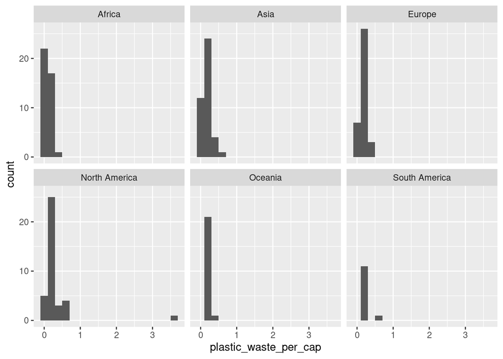

```r
ggplot(data = plastic_waste, aes(x = plastic_waste_per_cap)) +
  geom_histogram(binwidth = 0.2) +
  facet_wrap(~continent)
```

### Exercise 2

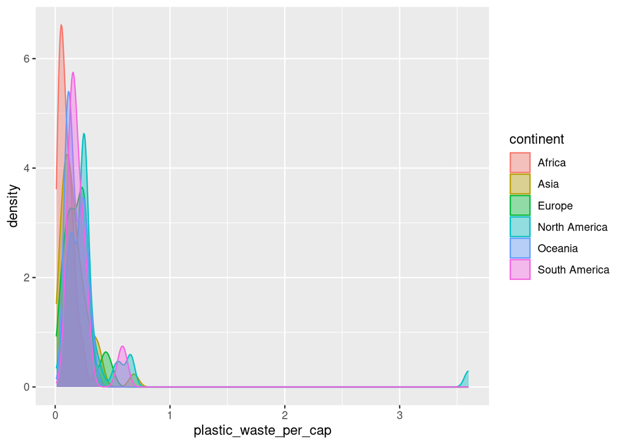

```r
ggplot(data = plastic_waste,
       mapping = aes(x = plastic_waste_per_cap,
                     color = continent,
                     fill = continent)) +
  geom_density(alpha = 0.4)
```

### Exercise 3

Because the color and fill aesthetics are mapped to the variables in the data. In this case, they were mapped to the continent variable, so that different colors would be used for different continents.

On the other hand, the alpha level is set outside the aes() function, because it is not mapped to any variable but is a fixed value applied to the geom_density(). All the variables share the same transparency now.

### Exercise 4

The violin plots reveal the density of the variables at different values and thus provide more information about the distribution than box plots. And violin plots are also more useful in showing the different peaks in the data. Box plots might be easier for us to directly compare the medians and interquartile ranges between groups.

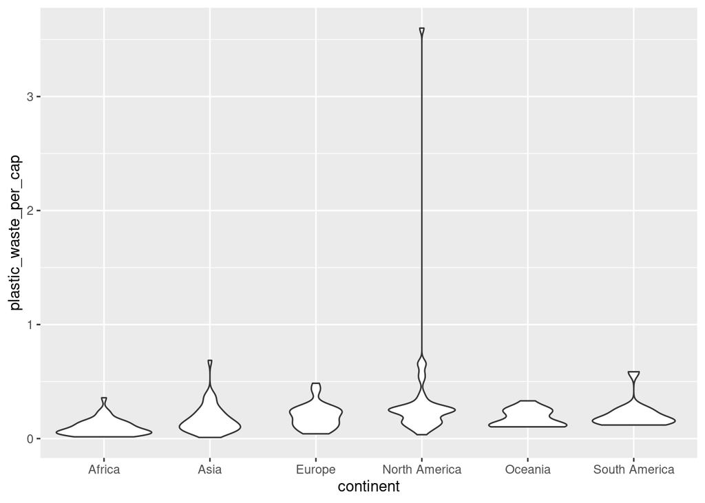

```r
ggplot(data = plastic_waste,
       mapping = aes(x = continent,
                     y = plastic_waste_per_cap)) +
  geom_violin()
```

### Exercise 5

The scatterplot shows a relatively positive relationship between plastic waste per capita and mismanaged plastic waste per capita, because as the plastic waste per capita increases, the mismanged plastic waste per capita also tend to increase. Also, the majority of data points are clustered near the origin, which means that many countries have both low plastic waste per capita and mismanaged plastic waste per capita.

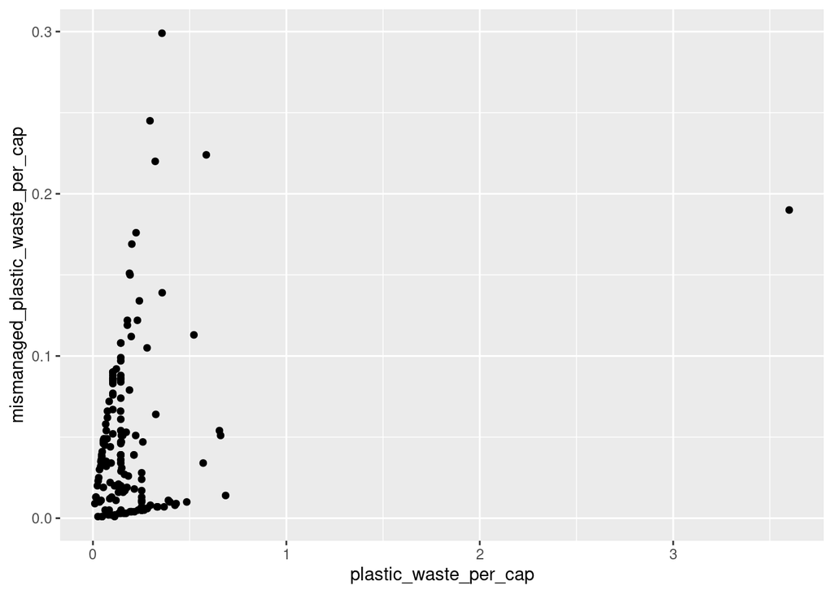

```r
ggplot(data = plastic_waste,
       mapping = aes(x = plastic_waste_per_cap,
                     y = mismanaged_plastic_waste_per_cap )) +
  geom_point()
```

### Exercise 6

I think there’s no clear distinctions between the continents because the scatterplot shows a general positive association between plastic waste per capita and mismanaged plastic waste per capita across different continents. For different continents, when the plastic waste per capita increases, the mismanaged plastic waste per capita also tends to increase.

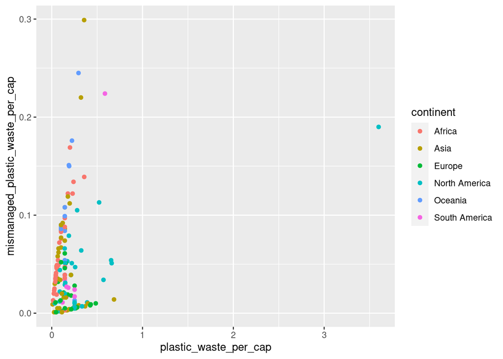

```r
ggplot(data = plastic_waste,
       mapping = aes(x = plastic_waste_per_cap,
                     y = mismanaged_plastic_waste_per_cap,
                     color = continent)) +
  geom_point()
```

### Exercise 7

The relationship between plastic waste per capita and the coastal population seems to be more linear associated. In the first scatterplot, the data points for total population versus plastic waste per capita seem to be more spreaded, especially for countries with larger populations, so there is no clear trend indicating a linear relationship.

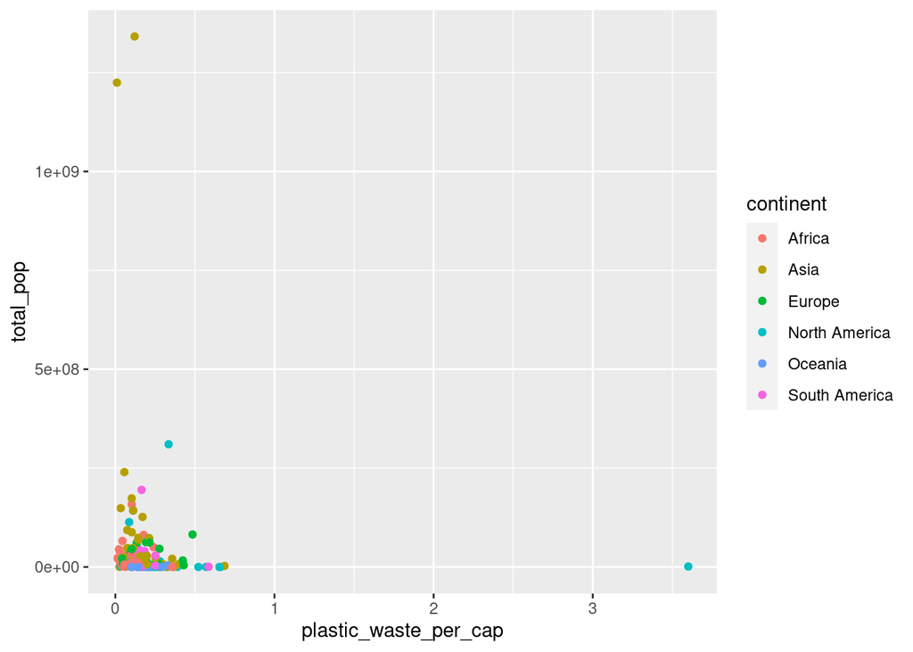

```r
ggplot(data = plastic_waste,
       mapping = aes(x = plastic_waste_per_cap,
                     y = total_pop,
                     color = continent)) +
  geom_point()
```

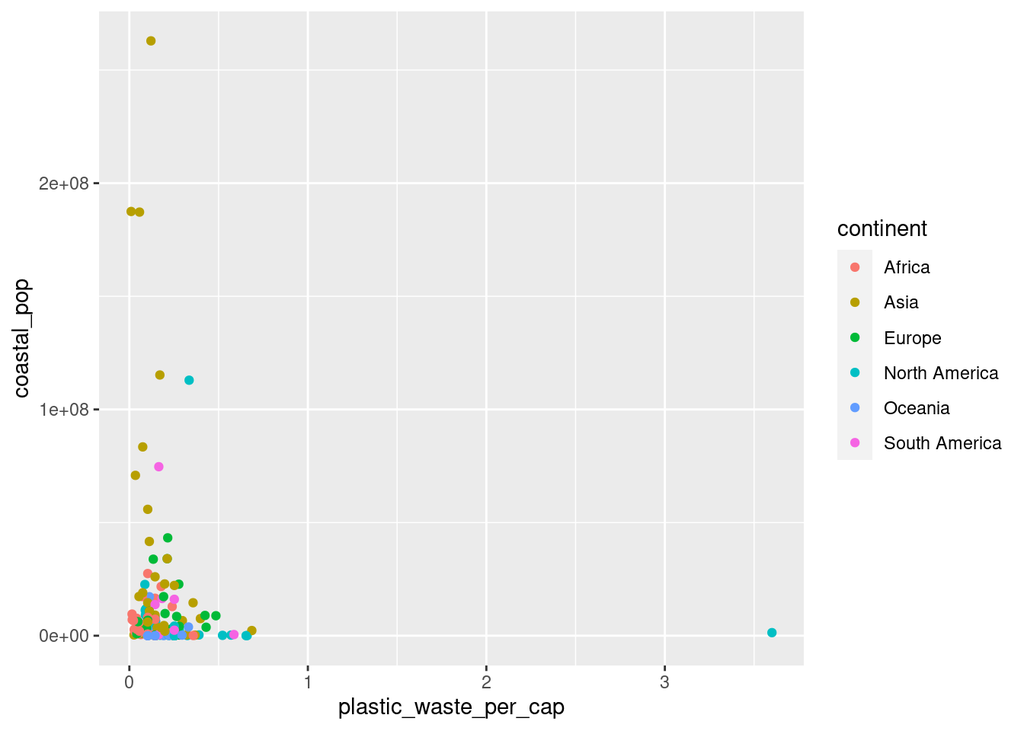

```r
ggplot(data = plastic_waste,
       mapping = aes(x = plastic_waste_per_cap,
                     y = coastal_pop,
                     color = continent)) +
  geom_point()
```

### Exercise 8

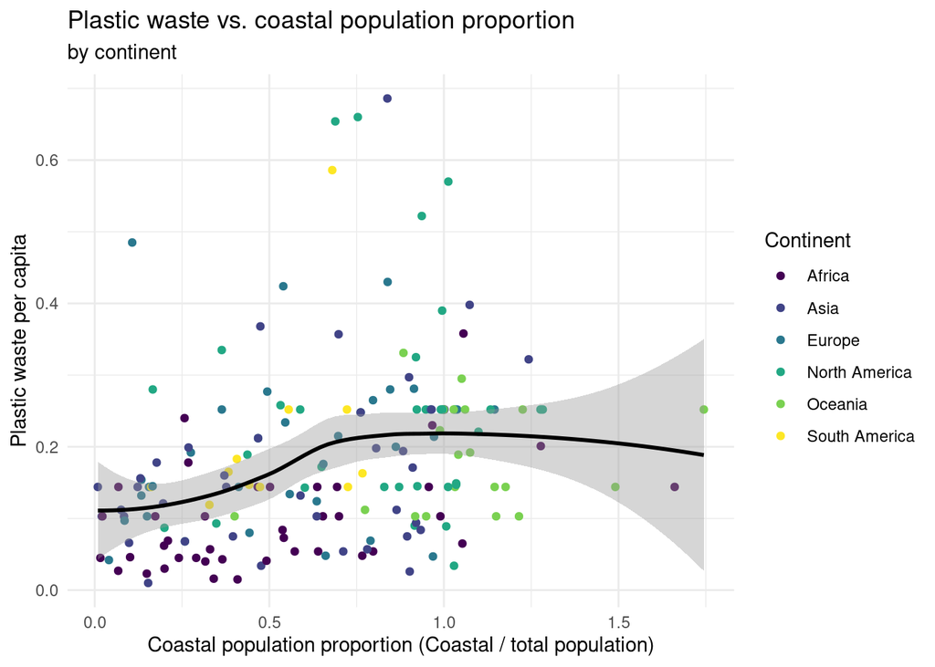

```r
# Mutate and filter
plastic_waste_new <- plastic_waste %>%
  mutate(coastal_pop_proportion = coastal_pop / total_pop) %>%
  filter(plastic_waste_per_cap <= 3)

# Create the plot
ggplot(data = plastic_waste_new,
            mapping = aes(x = coastal_pop_proportion, y = plastic_waste_per_cap, color = continent)) +
  geom_point() +
  geom_smooth(data = plastic_waste_new,
              mapping = aes(x = coastal_pop_proportion, y = plastic_waste_per_cap, color = continent),
              linetype = "solid", color = "black") +
  scale_color_viridis_d()+
  labs(x = 'Coastal population proportion (Coastal / total population)',
       y = 'Plastic waste per capita',
       color = 'Continent',
       title = 'Plastic waste vs. coastal population proportion',
       subtitle = 'by continent') +
  theme_minimal() # using the minimal theme
```

### Exercise 9

The smooth line in the middle, which shows the smoothed version of data points, tends to increase over x-axis and indicates an overall trend where the plastic waste per capita tends to increase with the coastal population proportion increasing to a certain point, after which it declines a little bit. Also, countries with less population living in coastal areas (proportion is relatively low) tend to generate less plastic waste per capita, while countries with more people living in coastal areas tend to have more plastic waste per capita. This might be due to coastal activities that generate plastic waste, such as tourism and fishing. However, around the right boundry of the curve, the decreasing trend may indicate that further increases in coastal population proportion may not increase plastic waste per capita anymore, which is similar to the diminishing marginal increases in waste generation.

Also, since the data points are colored by continents, we can see that some continents such as Africa tend to have low coastal population proportion (more people living far from coastal areas) and low plastic waste per capita, while some continents such as Oceania tend to have higher coastal population proportion (more people living around coastal areas) and higher plastic waste per capita. Therefore, continent might also be a crucial factor that affects plastic waste.